# Group 2 - Data Translation Challege Project Code

Lynna Tran, Chequala Fuller, Rosalie Sherry, Vishaal Diwan

3/19/2021

```
FALSE
FALSE ── Column specification ────────────────────────────────────────────────────────
FALSE cols(
FALSE   indname = col_character(),
FALSE   ind = col_double()
FALSE )
```

As this quarter comes to an end our research and findings culminate in answering three important questions about Covid-19 and its effect on employment. This paper seeks to answer the questions: How has Covid affected the health of the retail industry, how has retail fared to other industries, and who is working and earning money during this crisis. Looking at data from the last three years to get an understanding of employment and industry trends that began before the Covid-19 Global Pandemic this paper will answer these questions considering the various externalities that could also be affecting our data.

To begin it is important to investigate what data is being chosen. This paper grabbed all the covid data available, employment data across all sectors, demographics such as race, gender, age, and years of schooling, and information regarding health care and hours worked. It was then that the data was tidied and combined in order to get one dataset in which we could answer the questions at the core of our pursuit. It is important to note here that some data was dropped due to a lack of information from respondents thus the picture of the regression that this paper was hoping to build is not the regression we ended up with. The month of March in 2020 was also dropped as that seemed to be the transition period between the US before Covid and the US after Covid. With an unclear date as to when in March the change was officially made, it seemed best to take March out of the dataset. Thereby, the before Covid numbers end with February 2020 and the After Covid numbers begin with April 2020. This was set up as a binary variable in order to easily control for the before and after time period.

Now that the data that has been chosen has been discussed it is important to note the methodology in which the regressions were chosen and performed. For each regression it includes the binary variable of before and after Covid. To get a preliminary picture at employment, we regressed it against the before and after number. Resulting in an intercept of .4746. Giving us a picture of employment without any outside factors.

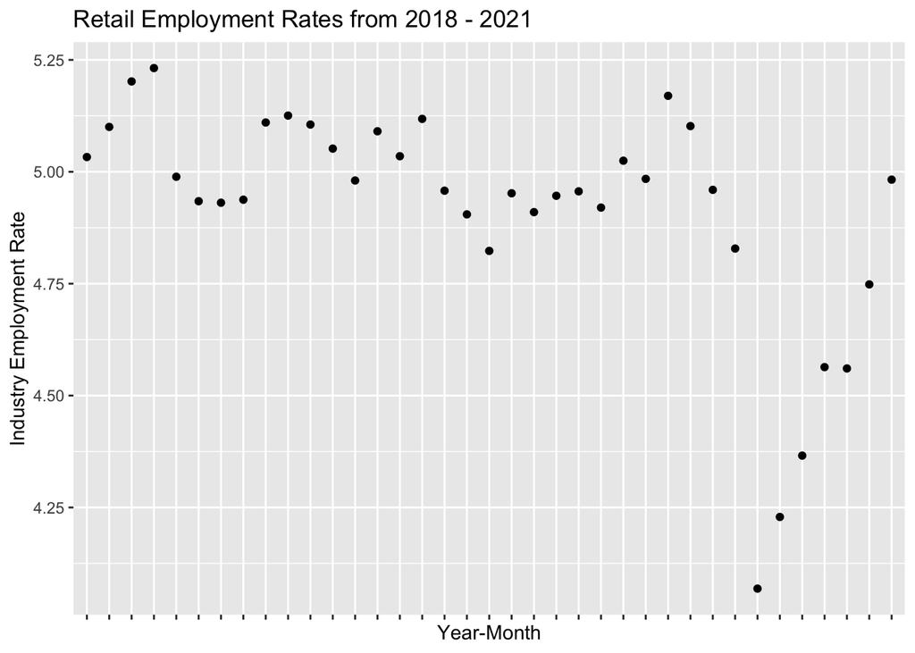

|  | Employment Regression |
| --- | --- |
| (Intercept) | 0.4746 *** |
|  | (0.0002) |
| N | 4288371 |
| R2 | 0.0000 |
| *** p < 0.001; ** p < 0.01; * p < 0.05. |  |

Next, we aimed to answer the first question by now looking at the regression, specifically by looking at the retail industry in comparison to employment. This showed a slightly lower intercept, which makes sense because we are adding in a variable which takes away part of the weight on the intercept. Looking at the coefficient on retail it is .4831, both the coefficient and intercept are considered to be statistically significant at the highest level. This regression provided the general health of the retail industry, which will allow us to properly compare the difference to that time after covid.

|  | Employment Regression with Retail Dummy Variable |
| --- | --- |
| (Intercept) | 0.4491 *** |
|  | (0.0002) |
| retail_noNATRUE | 0.4831 *** |
|  | (0.0011) |
| N | 4288371 |
| R2 | 0.0469 |
| *** p < 0.001; ** p < 0.01; * p < 0.05. |  |

Now, we get to the nitty gritty. How did retail fare during covid? Adding in the period after Covid and creating an interactive variable we can see the effect of covid on retail measure by employment. It is important to note that all numbers involved in this model are also statistically significant at the highest level, taking particular note of the covid significance which shows that it is highly unlikely the industry would have fared this way without such an effect. We still continue to see a positive retail coefficient but once we add in the interaction of Covid WITH retail we see that it has a negative effect of 0.0115 on overall employment. Clearly, the Covid-19 pandemic had a negative effect on the health of the retail industry.

|  | Employment Regression - Retail Interaction Term with COVID |
| --- | --- |
| (Intercept) | 0.4571 *** |
|  | (0.0003) |
| retail_noNATRUE | 0.4863 *** |
|  | (0.0012) |
| afterCovidTRUE | -0.0272 *** |
|  | (0.0005) |
| retail_noNATRUE:afterCovidTRUE | -0.0115 *** |
|  | (0.0023) |
| N | 4288371 |
| R2 | 0.0475 |
| *** p < 0.001; ** p < 0.01; * p < 0.05. |  |

Moving on to answer the next question at hand, it is important to get a fuller picture of the retail industry and how it has fared compared to other industries. Adjusting the regression to add all the other industries, we once again can fill in the gaps of understanding and paint a clearer picture of the effect of Covid on retail. Looking at the regression and sum table we see that practically every coefficient is significant. This is all done in comparison to retail so those with positive intercepts did better as compared to retail while those with negative fared worst. Looking at the transportation industry in particular this coefficient being negative would make sense because it was well documented that public transit and ride hailing apps suffered during the pandemic as people opted for safer alternatives that exposed them to less people. Meanwhile, the financial industry did relatively well compared to retail which is due to the fact that the financial industry was not put on hold or saw the same kind of restraints other industries saw.

```
FALSE `summarise()` has grouped output by 'YEAR', 'MONTH'. You can override using the `.groups` argument.
```

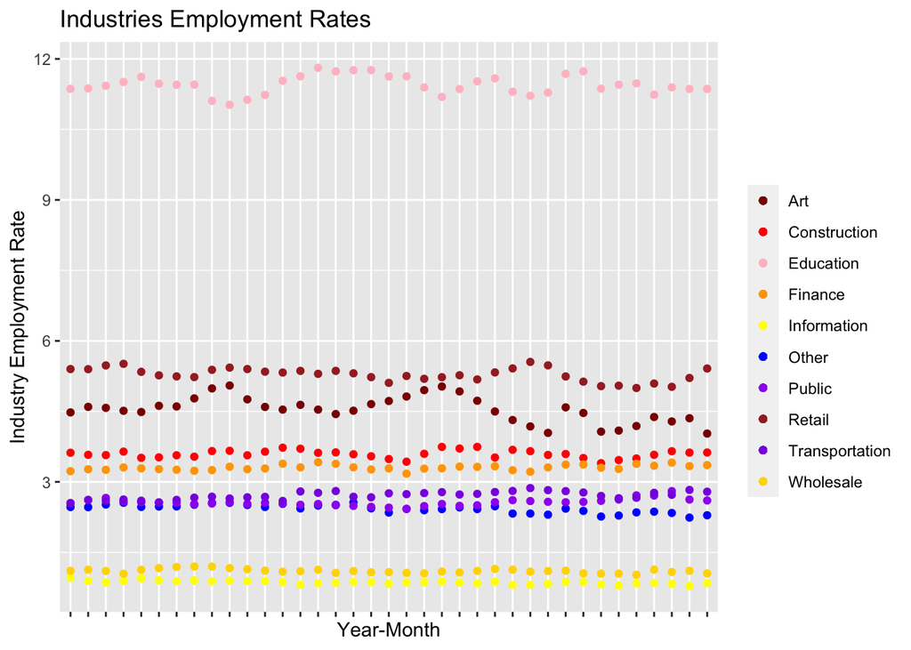

|  | Employment Regression with Other Industries |
| --- | --- |
| (Intercept) | 0.95 *** |
|  | (0.00) |
| artind | -0.02 *** |
|  | (0.00) |
| afterCovidTRUE | -0.04 *** |
|  | (0.00) |
| constructionind | -0.01 *** |
|  | (0.00) |
| eduind | 0.01 *** |
|  | (0.00) |
| financeind | 0.02 *** |
|  | (0.00) |
| infoind | 0.01 *** |
|  | (0.00) |
| otherind | 0.01 *** |
|  | (0.00) |
| proind | 0.00 *** |
|  | (0.00) |
| publicind | 0.02 *** |
|  | (0.00) |
| transportind | 0.01 *** |
|  | (0.00) |
| wsind | 0.01 *** |
|  | (0.00) |
| artind:afterCovidTRUE | -0.10 *** |
|  | (0.00) |
| afterCovidTRUE:constructionind | -0.00 |
|  | (0.00) |
| afterCovidTRUE:eduind | 0.00 *** |
|  | (0.00) |
| afterCovidTRUE:financeind | 0.02 *** |
|  | (0.00) |
| afterCovidTRUE:infoind | -0.01 ** |
|  | (0.00) |
| afterCovidTRUE:otherind | -0.03 *** |
|  | (0.00) |
| afterCovidTRUE:proind | 0.00 *** |
|  | (0.00) |
| afterCovidTRUE:publicind | 0.03 *** |
|  | (0.00) |
| afterCovidTRUE:transportind | -0.02 *** |
|  | (0.00) |
| afterCovidTRUE:wsind | 0.01 *** |
|  | (0.00) |
| N | 2140808 |
| R2 | 0.02 |
| *** p < 0.001; ** p < 0.01; * p < 0.05. |  |

Finally, we can answer the last question. Who fared well during the Covid-19 pandemic, or at least, who has money to spend? Looking at a regression on demographics including age, race, and education level we see that most people fared well that might be believed. A notable group that fared worse is women, who have a statistically significant coefficient at -0.10. It appears that those who did best during the pandemic is those with an education level resulting in a professional, doctorate, or master’s degree. The coefficients on race are in comparison to those of Asian descent and according to the coefficients those who are white fared the best. So those who fared the best are white men who are highly educated.

|  | Demographics Regression |
| --- | --- |
| (Intercept) | 0.20 *** |
|  | (0.00) |
| female | -0.10 *** |
|  | (0.00) |
| racialCategoriesBlack | 0.01 * |
|  | (0.00) |
| racialCategorieswhite | 0.06 *** |
|  | (0.00) |
| ageGenerationGeneration | 0.29 *** |
|  | (0.00) |
| ageGenerationGeneration Z | 0.06 *** |
|  | (0.00) |
| ageGenerationMillennial | 0.28 *** |
|  | (0.00) |
| highestEducationlevel11th grade | 0.06 *** |
|  | (0.00) |
| highestEducationlevel12th grade but no diploma | 0.11 *** |
|  | (0.00) |
| highestEducationlevel1st-4th grade | 0.14 *** |
|  | (0.01) |
| highestEducationlevel5th-8th grade | 0.10 *** |
|  | (0.00) |
| highestEducationlevel9th 'grade | 0.01 ** |
|  | (0.00) |
| highestEducationlevelAssociate degree or academic program | 0.31 *** |
|  | (0.00) |
| highestEducationlevelAssociate degree or occupational program | 0.31 *** |
|  | (0.00) |
| highestEducationlevelBachelors degree | 0.34 *** |
|  | (0.00) |
| highestEducationlevelDoctorate degree | 0.43 *** |
|  | (0.00) |
| highestEducationlevelHigh School graduate or GED | 0.23 *** |
|  | (0.00) |
| highestEducationlevelMasters degree | 0.37 *** |
|  | (0.00) |
| highestEducationlevelNo school | 0.04 *** |
|  | (0.01) |
| highestEducationlevelProfessional degree | 0.41 *** |
|  | (0.00) |
| highestEducationlevelSome college but no degree | 0.25 *** |
|  | (0.00) |
| N | 1169900 |
| R2 | 0.15 |
| *** p < 0.001; ** p < 0.01; * p < 0.05. |  |

Following this regression, this all makes sense as we look at news reports that state that Women are the most affected by unemployment during the Covid-19 Pandemic or reports that Unemployment numbers are high. Retail Employees work in places that were affected by things like fear of the virus as well as limits on occupancy and there was a surge in online shopping. So much so that places like Amazon that advertise their Prime Two-Day Shipping had to send notices that they could not keep with their newfound demand while managing Covid safety precautions. Looking at the numbers we have found we understand why the retail industry was so affected by the pandemic because it is one that was completely disrupted whereas other industries did not have the most essential part of their business model disturbed. Looking further into the data it leaves us wondering how this can apply in other ways. What types of retail business did worse than others? Did all sectors of the industry fare the same? The applications of this paper’s findings are certainly limitless.